# Data Cleaning

```python
import random
import numpy as np
import pandas as pd
import matplotlib.pyplot as plt
import seaborn as sns

import warnings
warnings.filterwarnings("ignore")
```

```python
df = pd.read_csv('data/package_locations.csv')
df['Zip Code'] = df['Zip Code'].str[:5]
df.head()
```

|  | Order ID | Zip Code | Longitude | Latitude | Package ID | Width | Length | Height | Weight |
| --- | --- | --- | --- | --- | --- | --- | --- | --- | --- |
| 0 | jQaRKEzCo27dRNnNu | 60622 | -87.684558 | 41.896016 | mb4cGEBYvSJrsFFQg | 16.0 | 23.0 | 2.0 | 4.0 |
| 1 | KxRjR6QbYrBDHio6i | 60618 | -87.714895 | 41.939587 | 9KWDDLMxtLwvfsHEB | 12.0 | 12.0 | 12.0 | 15.0 |
| 2 | nZ8Ffm4i7QwqgGbga | 60076 | -87.744326 | 42.018340 | 8KCnfP25BcCLiGx4t | 12.0 | 16.0 | 16.0 | 15.0 |
| 3 | NQipARuxiMXKa3WLy | 60614 | -87.636563 | 41.913992 | b5JpAAwZoGaFhNbbZ | 17.0 | 17.0 | 10.0 | 19.0 |
| 4 | 7ey2LZajFsGun3TGp | 60126 | -87.924939 | 41.901933 | pf6LNNg2gsjgmgMP9 | 12.0 | 14.0 | 8.0 | 10.0 |

- Restrict 'Zip Codes' to five digits.

```python
def summary(df):
    obs = df.shape[0]
    types = df.dtypes
    counts = df.apply(lambda x: x.count())
    uniques = df.apply(lambda x: x.unique().shape[0])
    nulls = df.apply(lambda x: x.isnull().sum())
    min = df.min()
    mean = df.mean()
    max = df.max()
    print('Data shape:', df.shape)

    cols = ['types', 'counts', 'uniques', 'nulls', 'min', 'mean', 'max']
    summary = pd.concat([types, counts, uniques, nulls,
                        min, mean,max], axis=1, sort=True)

    summary.columns = cols
    dtypes = summary.types.value_counts()
    print('___________________________\nData types:')
    print(summary.types.value_counts())
    print('___________________________')
    return summary

summary(df)
```

```
Data shape: (15709, 9)
___________________________
Data types:
float64    6
object     3
Name: types, dtype: int64
___________________________
```

|  | types | counts | uniques | nulls | min | mean | max |
| --- | --- | --- | --- | --- | --- | --- | --- |
| Height | float64 | 15152 | 11 | 557 | 0.0 | 10.337579 | 16.0 |
| Latitude | float64 | 15708 | 13267 | 1 | 39.580295 | 41.910249 | 42.460326 |
| Length | float64 | 15152 | 11 | 557 | 0.0 | 15.072004 | 23.0 |
| Longitude | float64 | 15708 | 12280 | 1 | -105.163131 | -87.859381 | 88.254208 |
| Order ID | object | 15709 | 15659 | 0 | 227phsiq9inRmkH9Y | NaN | zzwkARDjdbHt7gu4K |
| Package ID | object | 15709 | 15709 | 0 | 229knFkHDqFWcxwCD | NaN | zzgcojDfciNMsamua |
| Weight | float64 | 15036 | 10 | 673 | 0.0 | 12.911745 | 25.0 |
| Width | float64 | 15152 | 10 | 557 | 0.0 | 12.867410 | 17.0 |
| Zip Code | object | 15709 | 282 | 0 | 60004 | inf | 80401 |

- Summarize data types and ranges, unique and null values.

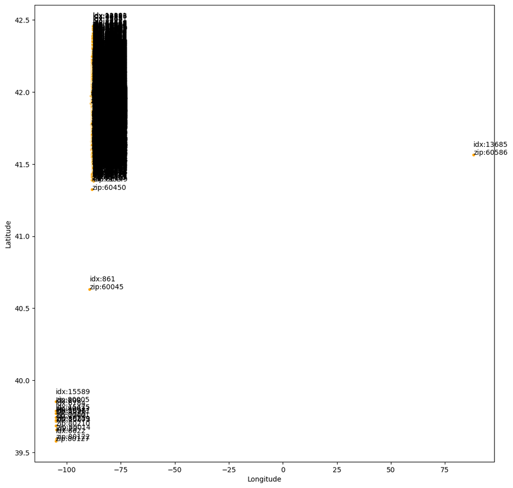

```python
plt.figure(figsize=(12,12))

sns.scatterplot(x=df.Longitude, y=df.Latitude, c=['orange'], s=20)

for i, txt in enumerate(df['Zip Code']):
    plt.annotate('idx:'+str(i)+'\nzip:'+txt, (df.Longitude[i], df.Latitude[i]))
```

- Inspect outliers.

```python
df.iloc[13685]
```

```
Order ID      RAQ3nvaDY28ARYvQJ
Zip Code                  60586
Longitude             88.254208
Latitude              41.566141
Package ID    ckbnfcdsG7NrH4qqm
Width                      12.0
Length                     16.0
Height                     13.0
Weight                     15.0
Name: 13685, dtype: object
```

- The first outlier is missing a negative Longtitude sign and can be corrected.

```python
df.iloc[861]
```

```
Order ID      83g9T7p8ZXGbMRmHY
Zip Code                  60045
Longitude            -89.398528
Latitude              40.633125
Package ID    9pNxBawNfhJPFWnte
Width                      14.0
Length                     16.0
Height                     14.0
Weight                     18.0
Name: 861, dtype: object
```

- The second outlier proves more difficult when attempting to identify the error.
- No simple adjustment matches a reasonable zip code.
- How many other zip codes do not match their coordinates?

```python
df[df['Longitude'].isna()]
```

|  | Order ID | Zip Code | Longitude | Latitude | Package ID | Width | Length | Height | Weight |
| --- | --- | --- | --- | --- | --- | --- | --- | --- | --- |
| 4999 | GaQPn7fmehJDPte97 | 60061 | NaN | NaN | NQCzw8kpF9oY8izbC | 10.0 | 16.0 | 8.0 | NaN |

- Missing coordinates will need to be removed.

```python
from geopy import Nominatim

geolocator = Nominatim(user_agent="veho")
bad_add = []

for i in range(len(df)):
    try:
        location = geolocator.reverse(str(df['Latitude'][i])+','+str(df['Longitude'][i]))
        a = location.address.split(',')[-2]
        if str(a).strip() != str(df['Zip Code'][i]).strip():
            bad_add.append(i)
    except:
        pass
```

```python
df = df.drop(bad_add)
df.reset_index(inplace=True)
df = df.drop(columns='index')
df.to_csv('data/good_addresses.csv')
```

- Drop instances where zip code and coordinates don't match. (Ironically, validating addresses proved more time consuming than any advanced algorithm)

```python
df = pd.read_csv('data/good_addresses.csv')
df['Zip Code'] = df['Zip Code'].astype('str')
df = df[df['Longitude'].notna()]
df = df.fillna(0)
df.loc[df['Width']==10, 'Weight'] = int(np.mean(df['Weight']))
df.loc[df['Longitude']>0, 'Longitude'] = df['Longitude'] * -1
df['Demand'] = df['Width'] * df['Length'] * df['Height']
df.reset_index(inplace = True)
df = df.drop(columns=['index','Unnamed: 0'])
```

# Exploratory Data Analysis

```python
df = df.sort_values('Zip Code')
```

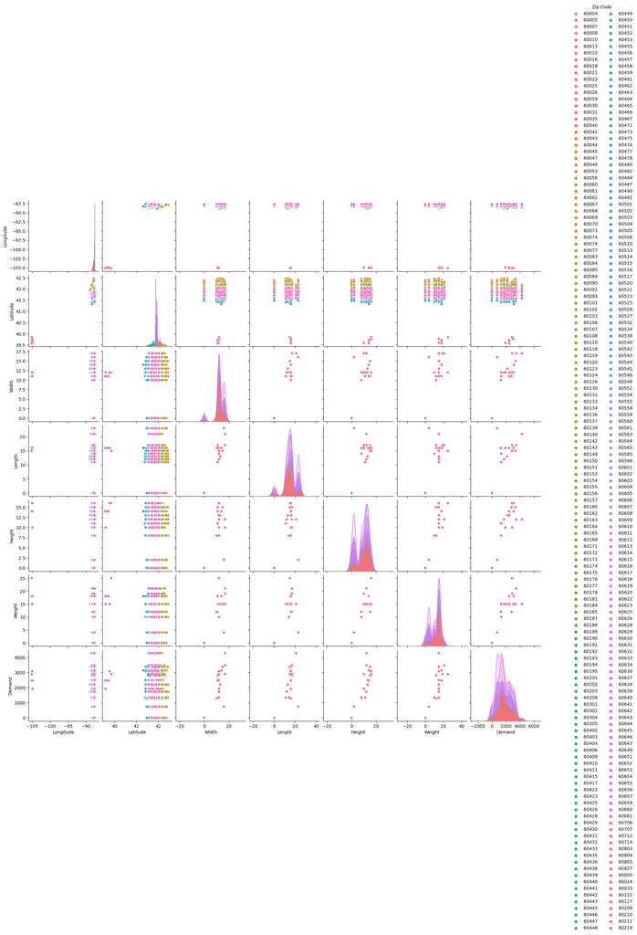

```python
g = sns.pairplot(df, hue='Zip Code')
sns.move_legend(g, bbox_to_anchor=(1.1, 0.5), loc=5, ncol=2, title='Zip Code', frameon=False)
```

Pairplot analysis identifies two clusters of addresses based on zip codes. Beyond that, we can identify trimodal distributions for width and length, as well as bimodal distributions for height and weight.

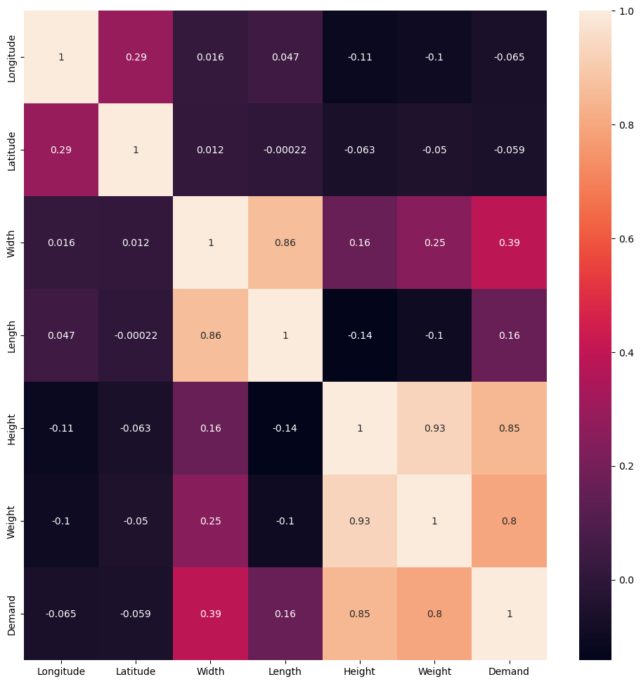

```python
plt.figure(figsize=(12,12))
sns.heatmap(df.corr(), annot=True)
```

The strongest correlation exists between Height and Weight. Although surprising, it could be an indication that Height is nearly always the name given to the greatest dimension.

```python
summary(df)
```

```
Data shape: (13917, 10)
___________________________
Data types:
float64    7
object     3
Name: types, dtype: int64
___________________________
```

|  | types | counts | uniques | nulls | min | mean | max |
| --- | --- | --- | --- | --- | --- | --- | --- |
| Demand | float64 | 13917 | 18 | 0 | 0.0 | 1832.116404 | 4284.0 |
| Height | float64 | 13917 | 10 | 0 | 0.0 | 10.072358 | 16.0 |
| Latitude | float64 | 13917 | 11797 | 0 | 39.580295 | 41.910101 | 42.460326 |
| Length | float64 | 13917 | 10 | 0 | 0.0 | 14.506647 | 23.0 |
| Longitude | float64 | 13917 | 10915 | 0 | -105.157648 | -87.882223 | -87.527975 |
| Order ID | object | 13917 | 13878 | 0 | 22Azydv6sFAYb9MzG | NaN | zzwkARDjdbHt7gu4K |
| Package ID | object | 13917 | 13917 | 0 | 229knFkHDqFWcxwCD | NaN | zzgcojDfciNMsamua |
| Weight | float64 | 13917 | 9 | 0 | 0.0 | 12.553352 | 25.0 |
| Width | float64 | 13917 | 9 | 0 | 0.0 | 12.424014 | 17.0 |
| Zip Code | object | 13917 | 280 | 0 | 60004 | inf | 80219 |

- Sanity Check; making sure no null values remain.

# Preprocessing

```python
chicago = df[df['Zip Code'].str.startswith('6')]
chicago.reset_index(inplace=True)
chicago = chicago.drop(columns=['index'])
denver = df[df['Zip Code'].str.startswith('8')]
denver.reset_index(inplace=True)
denver = denver.drop(columns=['index'])
denver
```

|  | Order ID | Zip Code | Longitude | Latitude | Package ID | Width | Length | Height | Weight | Demand |
| --- | --- | --- | --- | --- | --- | --- | --- | --- | --- | --- |
| 0 | Q4Nw6RsBwf2svs5Ab | 80005 | -105.151411 | 39.851961 | B6wzYfm5FYto9C2sB | 12.0 | 15.0 | 16.0 | 25.0 | 2880.0 |
| 1 | s9JzL3WLNhxwhNeDL | 80014 | -104.817076 | 39.659900 | KE9sv24j7qYC5jmHA | 11.0 | 16.0 | 14.0 | 18.0 | 2464.0 |
| 2 | QJ2AD4z2WCi2e7zPn | 80033 | -105.101366 | 39.788385 | 4iaNQcqcbt5A3Wk6y | 12.0 | 16.0 | 16.0 | 15.0 | 3072.0 |
| 3 | rpfr5dqSb2ez4vwsj | 80122 | -104.928185 | 39.592444 | 94udkrjMaNKS9ZEJJ | 12.0 | 16.0 | 10.0 | 15.0 | 1920.0 |
| 4 | RKNEfSFnejQocNKvy | 80127 | -105.157648 | 39.580295 | sFDGbP3rpny26LDGw | 11.0 | 16.0 | 14.0 | 18.0 | 2464.0 |
| 5 | rHjFeyvnYkoLSfcaJ | 80209 | -104.980095 | 39.716386 | CoGZeryPrFpLKxuPP | 11.0 | 16.0 | 14.0 | 18.0 | 2464.0 |
| 6 | jiohtfbTbbbLQG3Ev | 80210 | -104.976056 | 39.686399 | vMXZu6L84YkhwrsHq | 11.0 | 16.0 | 14.0 | 18.0 | 2464.0 |
| 7 | YLkzeu9bqGhpahN7y | 80211 | -105.015631 | 39.770947 | XpdMYs6Rc37sj7jDx | 12.0 | 16.0 | 16.0 | 15.0 | 3072.0 |
| 8 | zBKpwE7fHZidvdNQn | 80219 | -105.045399 | 39.722450 | KTWLxBDZxZiTHwRXX | 11.0 | 16.0 | 14.0 | 18.0 | 2464.0 |

- Separate the two zip code clusters into two datasets

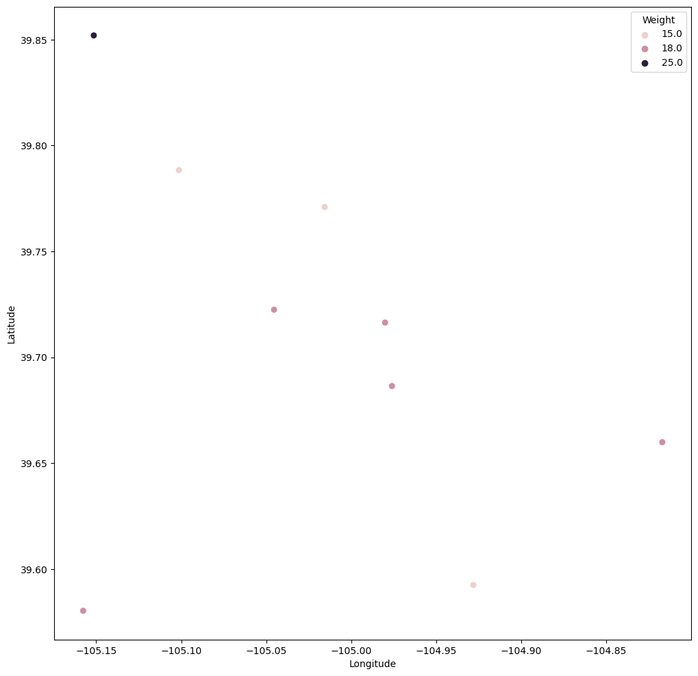

```python
plt.figure(figsize=(12,12))

sns.scatterplot(x=denver.Longitude, y=denver.Latitude, hue=denver.Weight, s=50)
```

- The Denver dataset represents a great primer for algorithm runtimes, because it is only 9 nodes.

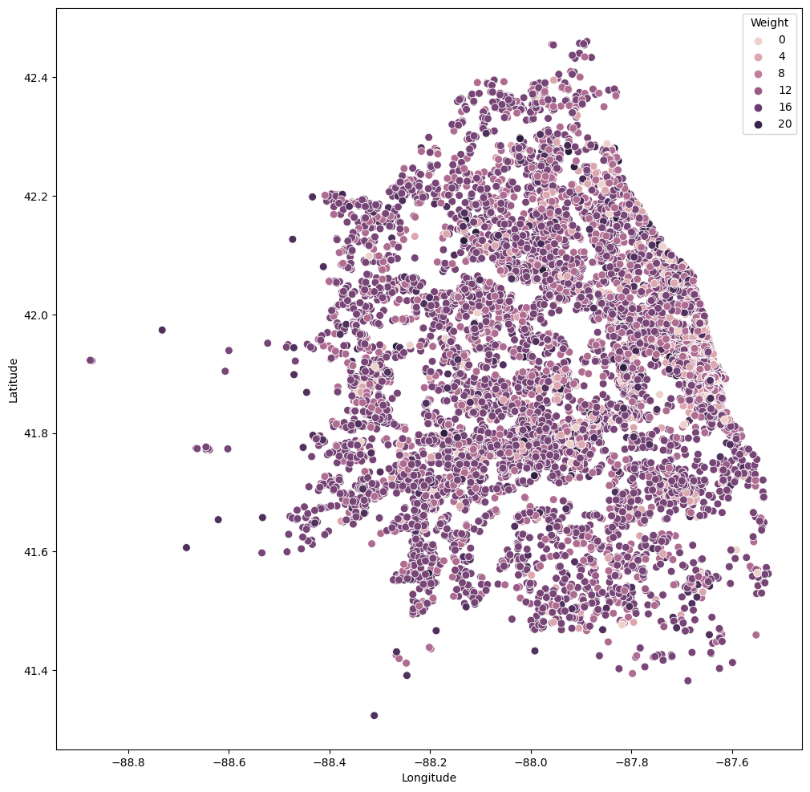

```python
plt.figure(figsize=(12,12))

sns.scatterplot(x=chicago.Longitude, y=chicago.Latitude, hue=chicago.Weight, s=50)
```

```python
# number of denver packages
den_n = denver.shape[0]
```

```python
# number of chicago packages
chi_n = chicago.shape[0]
```

```python
# minimum number of vehicles
den_k = int(round(sum(denver['Demand'])/57024, -1))
chi_k = int(round(sum(chicago['Demand'])/57024, -1))
```

```python
# average number of stops per vehicle
l = round(57024/np.mean(df['Demand']), -1)
```

- Establish variables for number of nodes, minimum number of routes/vehicles, mean nodes per vehicle

```python
with open(f'den{str(den_n)}.tsp', 'w') as f:
    f.write(f'''NAME : den{str(den_n)}
COMMENT : {str(den_n)} locations in Denver
COMMENT : Veho Data Prompt
TYPE : TSP
DIMENSION : {str(den_n)}
EDGE_WEIGHT_TYPE : EUC_2D
NODE_COORD_SECTION
''')
    for i in denver.index:
        f.write(f'''{i+1} {denver.Latitude[i]:0.3f} {denver.Longitude[i]:0.3f}
''')
    f.write('''EOF''')
```

```python
with open(f'chi{str(chi_n)}.tsp', 'w') as f:
    f.write(f'''NAME : chi{str(chi_n)}
COMMENT : {str(chi_n)} locations in Chicago
COMMENT : Veho Data Prompt
TYPE : TSP
DIMENSION : {str(chi_n)}
EDGE_WEIGHT_TYPE : EUC_2D
NODE_COORD_SECTION
''')
    for i in chicago.index:
        f.write(f'''{i+1} {chicago.Latitude[i]:0.3f} {chicago.Longitude[i]:0.3f}
''')
    f.write('''EOF''')
```

- Create TSP files for solver methods.

```
[[  41.91152571  -87.87113354]
 [  39.70768521 -105.01920752]]
```

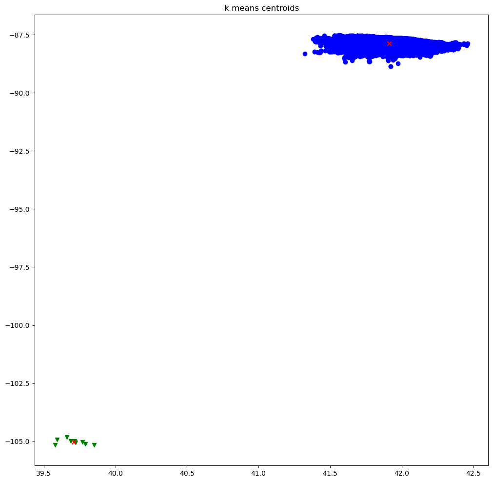

```python
 # clustering dataset
from sklearn.cluster import KMeans
from sklearn import metrics

x1 = np.array(df['Latitude'])
x2 = np.array(df['Longitude'])


# create new plot and data
X = np.array(list(zip(x1, x2))).reshape(len(x1), 2)
colors = ['b', 'g']
markers = ['o', 'v']

# KMeans algorithm
K = 2
kmeans_model = KMeans(n_clusters=K).fit(X)

print(kmeans_model.cluster_centers_)
centers = np.array(kmeans_model.cluster_centers_)


plt.figure(figsize=(12,12))
for i, l in enumerate(kmeans_model.labels_):
    plt.plot(x1[i], x2[i], color=colors[l], marker=markers[l],ls='None', zorder=-i)

plt.title('k means centroids')
plt.scatter(centers[:,0], centers[:,1], marker="x", color='r', zorder=0)
plt.show()
```

- Use Kmeans clustering to establish best coordinates for depot locations.

```python
denver.loc[-1] = ['Depot', 'depot', centers[1,1], centers[1,0], 'none', 0.0, 0.0, 0.0, 0.0, 0.0]  # adding depot
denver.index = denver.index + 1  # shifting index
denver = denver.sort_index()  # sorting by index
```

```python
chicago.loc[-1] = ['Depot', 'depot', centers[0,1], centers[0,0], 'none', 0.0, 0.0, 0.0, 0.0, 0.0]  # adding depot
chicago.index = chicago.index + 1  # shifting index
chicago = chicago.sort_index()  # sorting by index
```

```python
with open(f'DEN-n{str(den_n+1)}-k{den_k+1}.vrp', 'w') as f:
    f.write(f'''NAME : DEN-n{str(den_n+1)}-k{den_k+1}
COMMENT : (Denver, Min no of trucks: {den_k+1}, Optimal value: {den_k+1})
TYPE : CVRP
BEST_KNOWN: {den_k+1}
DIMENSION : {str(den_n+1)}
EDGE_WEIGHT_TYPE : GEO
CAPACITY : 57024
NODE_COORD_SECTION
''')
    for i in denver.index:
        f.write(f'''{i} {denver.Latitude[i]:0.3f} {denver.Longitude[i]:0.3f}
''')
    f.write('''DEMAND_SECTION
''')
    for i in denver.index:
        f.write(f'''{i} {denver.Demand[i]:0.3f}
''')
    f.write('''DEPOT_SECTION
''')
    f.write('''0
0
''')
    f.write('''EOF''')
```

```python
with open(f'CHI-n{str(chi_n+1)}-k{chi_k}.vrp', 'w') as f:
    f.write(f'''NAME : CHI-n{str(chi_n+1)}-k{chi_k}
COMMENT : (Chicago, Min no of trucks: {chi_k}, Optimal value: {chi_k})
TYPE : CVRP
BEST_KNOWN: {chi_k}
DIMENSION : {str(chi_n+1)}
EDGE_WEIGHT_TYPE : GEO
CAPACITY : 57024
NODE_COORD_SECTION
''')
    for i in chicago.index:
        f.write(f'''{i} {chicago.Latitude[i]:0.3f} {chicago.Longitude[i]:0.3f}
''')
    f.write('''DEMAND_SECTION
''')
    for i in chicago.index:
        f.write(f'''{i} {chicago.Demand[i]:0.3f}
''')
    f.write('''DEPOT_SECTION
''')
    f.write('''0
0
''')
    f.write('''EOF''')
```

- Create VRP files for solver methods.

# Solutions

## TSP: 2-opt

The Traveling Salesman Problem is a well known challenge in Computer Science: it consists on finding the shortest route possible that traverses all cities in a given map only once. Although its simple explanation, this problem is, indeed, NP-Complete. This implies that the difficulty to solve it increases rapidly with the number of cities, and we do not know in fact a general solution that solves the problem. For that reason, we currently consider that any method able to find a sub-optimal solution is generally good enough (we cannot verify if the solution returned is the optimal one most of the times).

**2-opt**

Among simple local search algorithms, the most famous are 2-Opt and 3-Opt. The 2-Opt algorithm was first proposed by Croes [1958], although the basic move had already been suggested by Flood [1956]. This move deletes two edges, thus breaking the tour into two paths, and then reconnects those paths in the other possible way. The main idea behind it is to take a route that crosses over itself and reorder it so that it does not.

```python
# Calculate the euclidian distance in n-space of the route r traversing nodes c, ending at the path start.
path_distance = lambda r,c: np.sum([np.linalg.norm(c[r[p]]-c[r[p-1]]) for p in range(len(r))])
# Reverse the order of all elements from element i to element k in array r.
two_opt_swap = lambda r,i,k: np.concatenate((r[0:i],r[k:-len(r)+i-1:-1],r[k+1:len(r)]))

def two_opt(nodes,improvement_threshold): # 2-opt Algorithm adapted from https://en.wikipedia.org/wiki/2-opt
    route = np.arange(nodes.shape[0])
    improvement_factor = 1
    best_distance = path_distance(route,nodes)
    while improvement_factor > improvement_threshold:
        distance_to_beat = best_distance
        for swap_first in range(1,len(route)-2):
            for swap_last in range(swap_first+1,len(route)):
                new_route = two_opt_swap(route,swap_first,swap_last)
                new_distance = path_distance(new_route,nodes)
                if new_distance < best_distance:
                    route = new_route
                    best_distance = new_distance
        improvement_factor = 1 - best_distance/distance_to_beat
    return route
```

```python
nodes = np.array([[denver.Latitude[i], denver.Longitude[i]] for i in denver.index])
route = two_opt(nodes,0.001)
```

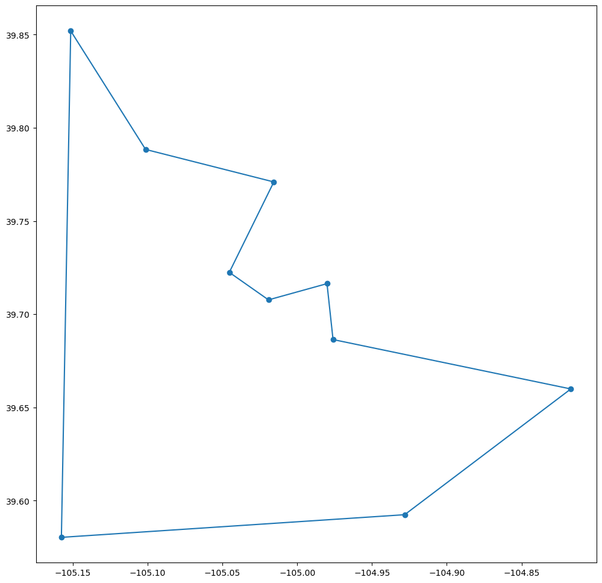

```
Route: [0 6 7 2 4 5 1 3 8 9]

Distance: 1.1183761343795042
```

```python
plt.figure(figsize=(12,12))
# Reorder the nodes matrix by route order in a new matrix for plotting.
new_nodes_order = np.concatenate((np.array([nodes[route[i]] for i in range(len(route))]),np.array([nodes[0]])))
# Plot the nodes.
plt.scatter(nodes[:,1],nodes[:,0])
# Plot the path.
plt.plot(new_nodes_order[:,1],new_nodes_order[:,0])
plt.show()
# Print the route as row numbers and the total distance travelled by the path.
print("Route: " + str(route) + "\n\nDistance: " + str(path_distance(route,nodes)))
```

*TSP solvers and .tsp files are traditionally evaluated using 2-dimensional Euclidean distance, which is why the distance above is in degrees and minutes.

**Examine the relationship between NP-Complete problems and Knot Theory.

## TSP: Self Organizing Map

**Self Organizing Map**

The original paper released by Teuvo Kohonen in 1998 consists on a brief, masterful description of the technique. In there, it is explained that a self-organizing map is described as an (usually two-dimensional) grid of nodes, inspired in a neural network. Closely related to the map, is the idea of the model, that is, the real world observation the map is trying to represent. The purpose of the technique is to represent the model with a lower number of dimensions, while maintaining the relations of similarity of the nodes contained in it.

On the other side, the neighborhood is defined as a convolution-like kernel for the map around the winner. Doing this, we are able to update the winner and the neurons nearby closer to the element, obtaining a soft and proportional result. The function is usually defined as a Gaussian distribution, but other implementations are as well. One worth mentioning is a bubble neighborhood, that updates the neurons that are within a radius of the winner (based on a discrete Kronecker delta function), which is the simplest neighborhood function possible.

To use the network to solve the TSP, the main concept to understand is how to modify the neighborhood function. If instead of a grid we declare a circular array of neurons, each node will only be conscious of the neurons in front of and behind it. That is, the inner similarity will work just in one dimension. Making this slight modification, the self-organizing map will behave as an elastic ring, getting closer to the cities but trying to minimize the perimeter of it thanks to the neighborhood function.

This expression is indeed quite similar to that of Q-Learning, and the convergence is search in a similar fashion to this technique. Decaying the parameters can be useful in unsupervised learning tasks like the aforementioned ones. It is also similar to the functioning of the Learning Vector Quantization technique, also developed by Teuvo Kohonen.

Finally, to obtain the route from the SOM, it is only necessary to associate a city with its winner neuron, traverse the ring starting from any point and sort the cities by order of appearance of their winner neuron in the ring. If several cities map to the same neuron, it is because the order of traversing such cities have not been contemplated by the SOM (due to lack of relevance for the final distance or because of not enough precision). In that case, any possible ordered can be considered for such cities.

```python
!python ../TSP/som-tsp/src/main.py chi13905.tsp
```

[output not shown]

```python
!python ../TSP/som-tsp/src/main.py den9.tsp
```

```
Problem with 9 nodes read.
Network of 72 neurons created. Starting the iterations:
Radius has completely decayed, finishing execution at 14253 iterations
Route found of length 1.1140670983781675
```

```python
from PIL import Image
import glob

# Create the frames
frames = []
imgs = glob.glob('diagrams/*.png')
imgs.sort()
for i in imgs:
    image=Image.open(i)
    non_transparent=Image.new('RGBA',image.size,(255,255,255,255))
    non_transparent.paste(image,(0,0),image)
    frames.append(non_transparent)

# Save into a GIF file that loops forever
frames[0].save('chicago.gif', format='GIF',
               append_images=frames[1:],
               save_all=True,
               duration=500, loop=0)
```

[figure not shown]

Because of it's reward system, or more simply put, laws of attraction. It's able to pass the geographical test of the Chicago River better than most. I would like to explore this algo in tandem with 2-opt and 3-opt more closely.

```python
from networkx import DiGraph
from vrpy import VehicleRoutingProblem
import pulp
import itertools
import sklearn
from sklearn.metrics.pairwise import haversine_distances
```

```python
def matrix(df):

    df[['long_radians','lat_radians']] = (
        np.radians(df.loc[:,['Longitude', 'Latitude']])
    )

    dist_matrix = haversine_distances(df[['lat_radians','long_radians']], df[['lat_radians','long_radians']])*3959

    # Note that 3959 is the radius of the earth in miles
    df_dist_matrix = (
        pd.DataFrame(dist_matrix,index=df.index,
                     columns=df.index)
    )

    return df_dist_matrix

def melt(matrix):

    df_dist_long = (
        pd.melt(matrix, ignore_index=False)
    )

    df_dist_long = df_dist_long.sort_values(by=['value']).reset_index()

    df_dist_long = df_dist_long.rename(columns={'index':'start', 'variable': 'end', 'value':'miles'})

    return df_dist_long
```

```python
den_mat = matrix(denver)
den_mat
```

|  | 0 | 1 | 2 | 3 | 4 | 5 | 6 | 7 | 8 | 9 |
| --- | --- | --- | --- | --- | --- | --- | --- | --- | --- | --- |
| 0 | 0.000000 | 12.192951 | 11.244259 | 7.081326 | 9.319796 | 11.477789 | 2.164204 | 2.725219 | 4.375331 | 1.725953 |
| 1 | 12.192951 | 0.000000 | 22.170626 | 5.133432 | 21.501273 | 18.774433 | 13.057837 | 14.751565 | 9.125581 | 10.571982 |
| 2 | 11.244259 | 22.170626 | 0.000000 | 17.523909 | 7.529449 | 18.943161 | 9.506344 | 8.651179 | 13.048077 | 12.886431 |
| 3 | 7.081326 | 5.133432 | 17.523909 | 0.000000 | 16.373689 | 14.686749 | 8.139617 | 9.695053 | 4.709459 | 5.440164 |
| 4 | 9.319796 | 21.501273 | 7.529449 | 16.373689 | 0.000000 | 12.247946 | 8.998379 | 6.973890 | 13.181603 | 10.935112 |
| 5 | 11.477789 | 18.774433 | 18.943161 | 14.686749 | 12.247946 | 0.000000 | 13.329045 | 12.129858 | 15.185133 | 11.495480 |
| 6 | 2.164204 | 13.057837 | 9.506344 | 8.139617 | 8.998379 | 13.329045 | 0.000000 | 2.083188 | 4.216318 | 3.496032 |
| 7 | 2.725219 | 14.751565 | 8.651179 | 9.695053 | 6.973890 | 12.129858 | 2.083188 | 0.000000 | 6.209079 | 4.449094 |
| 8 | 4.375331 | 9.125581 | 13.048077 | 4.709459 | 13.181603 | 15.185133 | 4.216318 | 6.209079 | 0.000000 | 3.705414 |
| 9 | 1.725953 | 10.571982 | 12.886431 | 5.440164 | 10.935112 | 11.495480 | 3.496032 | 4.449094 | 3.705414 | 0.000000 |

```python
den_long = melt(den_mat)
den_long
```

|  | start | end | miles |
| --- | --- | --- | --- |
| 0 | 0 | 0 | 0.000000 |
| 1 | 8 | 8 | 0.000000 |
| 2 | 7 | 7 | 0.000000 |
| 3 | 6 | 6 | 0.000000 |
| 4 | 5 | 5 | 0.000000 |
| ... | ... | ... | ... |
| 95 | 2 | 5 | 18.943161 |
| 96 | 1 | 4 | 21.501273 |
| 97 | 4 | 1 | 21.501273 |
| 98 | 2 | 1 | 22.170626 |
| 99 | 1 | 2 | 22.170626 |

100 rows × 3 columns

```python
chi_mat = matrix(chicago)
chi_mat
```

|  | 0 | 1 | 2 | 3 | 4 | 5 | 6 | 7 | 8 | 9 | ... | 13899 | 13900 | 13901 | 13902 | 13903 | 13904 | 13905 | 13906 | 13907 | 13908 |
| --- | --- | --- | --- | --- | --- | --- | --- | --- | --- | --- | --- | --- | --- | --- | --- | --- | --- | --- | --- | --- | --- |
| 0 | 0.000000 | 15.893235 | 15.886031 | 14.381582 | 14.312954 | 14.462854 | 12.715274 | 13.858960 | 17.760746 | 14.752824 | ... | 15.776456 | 16.048393 | 16.043210 | 15.288775 | 15.385240 | 15.408879 | 16.164806 | 15.954023 | 20.550840 | 20.368670 |
| 1 | 15.893235 | 0.000000 | 0.549348 | 2.746167 | 1.777750 | 1.588889 | 3.347681 | 2.371294 | 1.912546 | 1.623212 | ... | 31.520785 | 31.754795 | 31.761233 | 30.956729 | 31.077140 | 31.152491 | 31.832171 | 31.593784 | 36.194259 | 36.050558 |
| 2 | 15.886031 | 0.549348 | 0.000000 | 2.323587 | 1.600117 | 1.871530 | 3.220005 | 2.146346 | 1.882246 | 1.294533 | ... | 31.561915 | 31.802504 | 31.807056 | 31.009598 | 31.126563 | 31.193489 | 31.885909 | 31.651216 | 36.254804 | 36.105141 |
| 3 | 14.381582 | 2.746167 | 2.323587 | 0.000000 | 1.404202 | 2.843842 | 1.970107 | 1.113595 | 3.943117 | 1.172021 | ... | 30.151330 | 30.414134 | 30.412123 | 29.641138 | 29.745760 | 29.783308 | 30.518400 | 30.297257 | 34.902248 | 34.731942 |
| 4 | 14.312954 | 1.777750 | 1.600117 | 1.404202 | 0.000000 | 1.440686 | 1.620413 | 0.602531 | 3.479594 | 0.539163 | ... | 30.015869 | 30.261601 | 30.264638 | 29.473117 | 29.587203 | 29.647417 | 30.349953 | 30.118458 | 34.723772 | 34.569047 |
| ... | ... | ... | ... | ... | ... | ... | ... | ... | ... | ... | ... | ... | ... | ... | ... | ... | ... | ... | ... | ... | ... |
| 13904 | 15.408879 | 31.152491 | 31.193489 | 29.783308 | 29.647417 | 29.654830 | 28.072661 | 29.220834 | 33.048939 | 30.107277 | ... | 0.368453 | 0.718123 | 0.671162 | 0.700243 | 0.484407 | 0.000000 | 1.004424 | 1.044745 | 5.192472 | 4.975159 |
| 13905 | 16.164806 | 31.832171 | 31.885909 | 30.518400 | 30.349953 | 30.322083 | 28.784991 | 29.933675 | 33.733758 | 30.816338 | ... | 0.796354 | 0.359769 | 0.466439 | 0.877334 | 0.796911 | 1.004424 | 0.000000 | 0.319360 | 4.386098 | 4.219272 |
| 13906 | 15.954023 | 31.593784 | 31.651216 | 30.297257 | 30.118458 | 30.080368 | 28.556705 | 29.705407 | 33.496666 | 30.586794 | ... | 0.944483 | 0.584881 | 0.692115 | 0.690723 | 0.694394 | 1.044745 | 0.319360 | 0.000000 | 4.606220 | 4.458977 |
| 13907 | 20.550840 | 36.194259 | 36.254804 | 34.902248 | 34.723772 | 34.677037 | 33.162840 | 34.311540 | 38.098306 | 35.192701 | ... | 4.834557 | 4.516825 | 4.533542 | 5.262629 | 5.168178 | 5.192472 | 4.386098 | 4.606220 | 0.000000 | 0.420925 |
| 13908 | 20.368670 | 36.050558 | 36.105141 | 34.731942 | 34.569047 | 34.538724 | 33.003202 | 34.151859 | 37.952577 | 35.034965 | ... | 4.611800 | 4.320340 | 4.327944 | 5.095934 | 4.986189 | 4.975159 | 4.219272 | 4.458977 | 0.420925 | 0.000000 |

13909 rows × 13909 columns

```python
chi_long = melt(chi_mat)
chi_long
```

|  | start | end | miles |
| --- | --- | --- | --- |
| 0 | 0 | 0 | 0.000000 |
| 1 | 7393 | 7393 | 0.000000 |
| 2 | 7394 | 7394 | 0.000000 |
| 3 | 7395 | 7395 | 0.000000 |
| 4 | 7396 | 7396 | 0.000000 |
| ... | ... | ... | ... |
| 193460276 | 5381 | 2428 | 81.118902 |
| 193460277 | 2430 | 5381 | 81.169669 |
| 193460278 | 5381 | 2430 | 81.169669 |
| 193460279 | 5381 | 2427 | 81.516145 |
| 193460280 | 2427 | 5381 | 81.516145 |

193460281 rows × 3 columns

## 3D Bin Packing

Because the SOM gave us a suboptimal solution to our routing problem, we can now iterate through the route one truck at a time to see the minimum amount of trucks at capacity it will take to complete the route. Unfortunately, the 3D binning algorithm we are using is O(n)2 at best, and O(n)3 at worst. This could be improved by parallel processing at some point, if not by simply improving the algorithm.

```python
with open('route.txt', 'r') as f:
    route = [line.split()[0] for line in f.readlines()]
    dist = 0
    for a, b in zip(route, route[1:]):
        dist += den_mat[int(a)][int(b)]

print(dist, 'miles')
```

```
87.25918901434022 miles
```

```python
from py3dbp import Packer, Bin, Item
from collections import deque

queue = deque(route)
packer = Packer()
number = 1

while len(queue) > 0:
    b = Bin(f'Route {number}', 38.49, 38.49, 38.49, 500000)
    packer.add_bin(b)
    if len(b.unfitted_items) == 0:
        i = queue.popleft()
        packer.add_item(Item(i, denver.loc[int(i)]['Width'], denver.loc[int(i)]['Length'], denver.loc[int(i)]['Height'], chicago.loc[int(i)]['Weight']))
        packer.pack()
    else:
        number += 1
```

```python
b = packer.bins[-1]
print(":::::::::::", b.string())

print("FITTED ITEMS:")
dist = 0
for i,j in zip(b.items, b.items[1:]):
    dist += den_mat[int(i.string()[0])][int(j.string()[0])]
    print("====> ", j.string()[0], ':', dist, 'miles')

print("***************************************************")
print("***************************************************")
```

```
::::::::::: Route 1(38.490x38.490x38.490, max_weight:500000.000) vol(57022.169)
FITTED ITEMS:
====>  4 : 9.319795891390228 miles
====>  2 : 16.849244972102095 miles
====>  7 : 25.500423622076333 miles
====>  5 : 37.630281720837175 miles
====>  6 : 50.95932676490349 miles
====>  1 : 64.01716410343339 miles
====>  8 : 73.1427452215115 miles
====>  3 : 77.85220417031624 miles
```

## CVRP: Greedy, Savings, and Pulp Optimization

**Greedy**

Some authors use the name Greedy for Nearest Neighbor, but it is more appropriately reserved for the following special case of the ‘‘greedy algorithm’’ of matroid theory. In this heuristic, we view an instance as a complete graph with the cities as vertices and with an edge of length d(c i,c j) between each pair {c i,c j} of cities. A tour is then simply a Hamiltonian cycle in this graph, i.e., a connected collection of edges in which every city has degree 2. We build up this cycle one edge at a time, starting with the shortest edge, and repeatedly adding the shortest remaining available edge, where an edge is available if it is not yet in the tour and if adding it would not create a degree-3 vertex or a cycle of length less than N. (In view of the intermediate partial tours typically constructed by this heuristic, it is called the multi-fragment heuristic by Bentley [1990a,1992]). The Greedy heuristic can be implemented to run in time Θ(N2 logN) and is thus somewhat slower than NN. On the other hand, its worst-case tour quality may be somewhat better. As with NN, it can be shown that Greedy(I)/OPT (I) ≤ ( 0. 5 ) ([log 2N] + 1 ) for all instances I obeying the triangle inequality [Moore, 1984], but the worst examples known for Greedy only make the ratio grow as ( logN)/( 3 log log N) [Frieze,1979].

**Clarke-Wright**

The Clarke-Wright savings heuristic (Clarke-Wright or simply CW for short) is derived from a more general vehicle routing algorithm due to Clarke and Wright [1964]. In terms of the TSP, we start with a pseudo-tour in which an arbitrarily chosen city is the hub and the salesman returns to the hub after each visit to another city. (In other words, we start with a multigraph in which every non-hub vertex is connected by two edges to the hub). For each pair of non-hub cities, let the savings be the amount by which the tour would be shortened if the salesman went directly from one city to the other, bypassing the hub. We now proceed analogously to the Greedy algorithm. We go through the non-hub city pairs in non-increasing order of savings, performing the bypass so long as it does not create a cycle of non-hub vertices or cause a non-hub vertex to become adjacent to more than two other non-hub vertices. The construction process terminates when only two non-hub cities remain connected to the hub, in which case we have a true tour. As with Greedy, this algorithm can be implemented to run in time Θ(N 2 logN). The best performance guarantee currently known (assuming the triangle inequality) is CW(I)/OPT (I) ≤ [log 2N] + 1 (a factor of 2 higher than that for Greedy) [Ong & Moore, 1984], but the worst examples known yield the same ( logN)/( 3 log log N) ratio as obtained for Greedy [Frieze, 1979].

```python
D = DiGraph()

for i in range(len(den_long)):
    a = den_long.start[i]
    b = den_long.end[i]
    c = den_long.miles[i]
    if a == 0:
        a = 'Source'
    if b == 0:
        b = 'Sink'
    D.add_edge(a,b,cost=c)

for i in range(1, len(denver)):
    D.nodes[i]['demand'] = denver['Demand'][i]

prob = VehicleRoutingProblem(D, load_capacity=57024)

prob.solve()
prob.best_routes
```

```
INFO:vrpy.vrp:new upper bound : max num stops = 11
INFO:vrpy.vrp:Clarke & Wright solution found with value 69.9542163781727 and 2 vehicles
INFO:vrpy.vrp:Greedy solution found with value 73.1532298813241 and 1 vehicles
INFO:vrpy.vrp:iteration 0, 69.954
INFO:vrpy.vrp:iteration 1, 69.954
INFO:vrpy.vrp:iteration 2, 69.954
INFO:vrpy.vrp:iteration 3, 69.954
INFO:vrpy.vrp:iteration 4, 69.954
INFO:vrpy.vrp:iteration 5, 69.954
INFO:vrpy.vrp:iteration 6, 69.954
INFO:vrpy.vrp:iteration 7, 69.954
INFO:vrpy.vrp:iteration 8, 69.954
INFO:vrpy.vrp:iteration 9, 69.954
INFO:vrpy.vrp:iteration 10, 69.954
INFO:vrpy.vrp:iteration 11, 69.954
INFO:vrpy.vrp:iteration 12, 69.954
INFO:vrpy.vrp:iteration 13, 69.954
INFO:vrpy.vrp:iteration 14, 69.954
INFO:vrpy.vrp:iteration 15, 69.954
INFO:vrpy.vrp:iteration 16, 68.835
INFO:vrpy.vrp:iteration 17, 68.835
INFO:vrpy.vrp:iteration 18, 68.835
INFO:vrpy.vrp:iteration 19, 68.835
INFO:vrpy.vrp:iteration 20, 68.434
INFO:vrpy.vrp:iteration 21, 68.434
INFO:vrpy.vrp:iteration 22, 68.434
INFO:vrpy.vrp:iteration 23, 68.434
INFO:vrpy.vrp:iteration 24, 67.630
INFO:vrpy.vrp:iteration 25, 67.630
INFO:vrpy.master_solve_pulp:total cost = 67.63099940737503
```

```
{1: ['Source', 5, 4, 2, 7, 6, 8, 1, 3, 9, 'Sink']}
```

```python
C = DiGraph()

for i in range(len(chi_long)):
    a = chi_long.start[i]
    b = chi_long.end[i]
    c = chi_long.miles[i]
    if a == 0:
        a = 'Source'
    if b == 0:
        b = 'Sink'
    D.add_edge(a,b,cost=c)

for i in range(1, len(chicago)):
    D.nodes[i]['demand'] = chicago['Demand'][i]

prob = VehicleRoutingProblem(C, load_capacity=57024)

prob.solve()
prob.best_routes
```

[output not shown]

## CVRP: Christofides, Generalized Assignment, Sweep, 3-opt, Parallel and Sequential Savings, Insertion, Nearest Neighbor, et cetera

```python
!python ../VRP/VRP.py -a all DEN-n10-k1.vrp
```

```
Solving DEN-n10-k1 with CW64-PS

SIZE: 10
CAPACITY: 57024
DISTANCE: None
SERVICE_TIME: None

SOLUTION: [0, 6, 7, 2, 4, 5, 3, 1, 8, 9, 0]
FEASIBLE: True
SOLUTION K: 1
SOLUTION LENGTH: 77.11672962049798


Solving DEN-n10-k1 with RT79-CAWLIP

SIZE: 10
CAPACITY: 57024
DISTANCE: None
SERVICE_TIME: None

SOLUTION: [0, 6, 7, 2, 4, 5, 1, 3, 8, 9, 0]
FEASIBLE: True
SOLUTION K: 1
SOLUTION LENGTH: 76.79794263555789


Solving DEN-n10-k1 with Ga67-PS|pi+lamda

SIZE: 10
CAPACITY: 57024
DISTANCE: None
SERVICE_TIME: None

SOLUTION: [0, 2, 4, 7, 6, 9, 8, 3, 1, 5, 0]
FEASIBLE: True
SOLUTION K: 1
SOLUTION LENGTH: 85.28389787534057


Solving DEN-n10-k1 with We64-SS
```

[output cut: 212 more lines]

[output not shown]

```python
!python ../VRP/VRP.py -a all CHI-n13906-k450.vrp
```

## Implemented Heuristics with References

`2o` : Croes & Flood (1958) two phase heuristic.

> CF58-2O: G. A. CROES (1958). A method for solving traveling salesman problems. Operations Res. 6 (1958), pp., 791-812.

> and

> M. M. FLOOD (1956). The traveling-salesman problem. Operations Res. 4 (1956), pp., 61-75.

`cmt` : Christofides, Mingozzi & Toth (1979) two phase heuristic.

> CMT79-2P: Christofides, N., Mingozzi, A., and Toth, P. (1979). The vehicle routing problem. In Christofides, N., Mingozzi, A., Toth, P., and Sandi, C., editors, Combinatorial Optimization, chapter 11, pages 315-338. Wiley.

`gap` : Fisher & Jaikumar (1981) generalized assignment problem (GAP) heuristic. *Requires Gurobi.*

> FJ81-GAP: Fisher, M. L. and Jaikumar, R. (1981). A generalized assignment heuristic for vehicle routing. Networks, 11(2):109-124.

`gm` : Gillett & Miller (1974) Sweep algorithm with emering route improvement step.

`swp` : Sweep algorithm without any route improvement heuristics.

> GM74-SwRI: Gillett, B. E. and Miller, L. R. (1974). A heuristic algorithm for the vehicle-dispatch problem. Operations Research, 22(2):340-349.

`gpl` : Parallel savings algorithm with Gaskell (1967) with the 𝜋 and 𝜆 criteria.

> Ga67-PS|𝜋𝜆: Gaskell, T. (1967). Bases for vehicle fleet scheduling. Journal of the Operational Research Society, 18(3):281-295.

`gps` : Paessens (1988) parametrized parallel savings algorithm.

> Pa88-PS|G2P: Paessens, H. (1988). The savings algorithm for the vehicle routing problem. European Journal of Operational Research, 34(3):336-344.

`ims` : Holmes & Parker (1976) parallel savings supression algorithm.

> HP76-PS|IMS: Holmes, R. and Parker, R. (1976). A vehicle scheduling procedure based upon savings and a solution perturbation scheme. Journal of the Operational Research Society, 27(1):83-92.

`lr3o` : Stewart & Golden (1984) 3-opt* heuristic with Lagrangian relaxations.

> SG84-LR3OPT: Stewart, W. R. and Golden, B. L. (1984). A Lagrangean relaxation heuristic for vehicle routing. European Journal of Operational Research, 15(1):84-88.

`mbsa` : Desrochers and Verhoog (1989) maximum matching problem solution based savings algorithm. *Requires Gurobi.*

> DV89-MM: Desrochers, M. and Verhoog, T. W. (1989). G-89-04 : A matching based savings algorithm for the vehicle routing problem. Technical report, GERAD, Montreal, Canada.

`mj` : Mole & Jameson (1976) sequential cheapest insertion heuristic with a route improvement phase.

> MJ76-INS: Mole, R. and Jameson, S. (1976). A sequential route-building algorithm employing a generalised savings criterion. Journal of the Operational Research Society, 27(2):503-511.

`ps` : Clarke & Wright (1964) parallel savings algorithm.

> CW64-PS:Clarke, G. and Wright, J. W. (1964). Scheduling of vehicles from a central depot to a number of delivery points. Operations Research, 12(4):568-581.

`ptl` : Foster & Ryan (1976) Petal set covering algorithm. *Requires Gurobi.*

> FR76-1PTL: Foster, B. A. and Ryan, D. M. (1976). An integer programming approach to the vehicle scheduling problem. Journal of the Operational Research Society, 27(2):367-384.

`pi`, vB94-PI : parallel insertion heuristic as described by van Breedam (1994, 2002).

`pn`, vB94-PNN : Parallel Nearest Neighbor construction heuristic.

`si`, vB94-SI : Sequential cheapest insertion heuristic without local search (van Breedam 1994, 2002).

`sn`, vB94-SNN : Sequential Nearest Neighbor construction heuristic as described by van Breedam (1994).

> vB94: Van Breedam, A. (1994). An Analysis of the Behavior of Heuristics for the Vehicle Routing Problem for a Selectrion of Problems with Vehicle-related, Customer-related, and Time-related Constraints. PhD thesis, Faculty of Applied Economics, University of Antwerp, Belgium - RUCA.

> and

> Van Breedam, A. (2002). A parametric analysis of heuristics for the vehicle routing problem with side-constraints. European Journal of Operational Research, 137(2):348-370.

`rfcs` : Route-first-cluster-second heuristic of Beasley (1983).

> Be83-RFCS: Beasley, J. E. (1983). Route first - cluster second methods for vehicle routing. Omega, 11(4):403-408.

`ss` : Webb (1964) sequential savings algorithm.

> We64-SS: Webb, M. (1964). A study in transport routing. Glass Technology, 5:178-181.

`ty` : Tyagi (1968) Nearest Neighbor construction heuristic.

> Ty68-NN: Tyagi, M. S. (1968). A practical method for the truck dispatching problem. Journal of the Operations Research Society of Japan, 10:76-92.

`wh` : Sweep heuristic with Wren and Holliday (1972) improvement procedures.

> WH72-SwLS: Wren, A. and Holliday, A. (1972). Computer scheduling of vehicles from one or more depots to a number of delivery points. Journal of the Operational Research Society, 23(3):333-344.

# TO DO

- Kmeans Constrained Clustering on Chicago data.
- Visualize 3d binning.
- Visualize 3-opt algorithm.